# Week 5: Dimensionality reduction techniques

```r
date()
```

```
## [1] "Sun Dec  5 20:32:25 2021"
```

## 1 Graphical overview and summaries of variables (3p)

The data includes 155 observations and the following 8 variables related to human development globally:

- GNI: Gross National Income per capita
- LEB: Life expectancy at birth
- EYE: Expected years of schooling
- MMR: Maternal mortality ratio
- ABR: Adolescent birth rate
- PRP: Proportion of female representatives in parliament
- edu2R: Ratio between females and males with at least secondary education (if > 1, larger portion of female are educated than men)
- labR: Ratio between females and males in the labour force (if > 1, larger portion of female are part of labour force than men)

I will start by reading the data and looking at the graphical overview and summary of the variables:

```r
library(dplyr)
```

```r
library(ggplot2)
library(GGally)
library(tidyr)
#library(boot)
library(corrplot)
library(FactoMineR)

# load the data
human <- read.csv("data/human.csv", header = TRUE, stringsAsFactors = TRUE, row.names = 1)

# summaries of the variables
summary(human)
```

```
##      edu2R             labR             LEB             EYE
##  Min.   :0.1717   Min.   :0.1857   Min.   :49.00   Min.   : 5.40
##  1st Qu.:0.7264   1st Qu.:0.5984   1st Qu.:66.30   1st Qu.:11.25
##  Median :0.9375   Median :0.7535   Median :74.20   Median :13.50
##  Mean   :0.8529   Mean   :0.7074   Mean   :71.65   Mean   :13.18
##  3rd Qu.:0.9968   3rd Qu.:0.8535   3rd Qu.:77.25   3rd Qu.:15.20
##  Max.   :1.4967   Max.   :1.0380   Max.   :83.50   Max.   :20.20
##       GNI              MMR              ABR              PRP
##  Min.   :  2.00   Min.   :   1.0   Min.   :  0.60   Min.   : 0.00
##  1st Qu.: 53.50   1st Qu.:  11.5   1st Qu.: 12.65   1st Qu.:12.40
##  Median : 99.00   Median :  49.0   Median : 33.60   Median :19.30
##  Mean   : 98.73   Mean   : 149.1   Mean   : 47.16   Mean   :20.91
##  3rd Qu.:143.50   3rd Qu.: 190.0   3rd Qu.: 71.95   3rd Qu.:27.95
##  Max.   :194.00   Max.   :1100.0   Max.   :204.80   Max.   :57.50
```

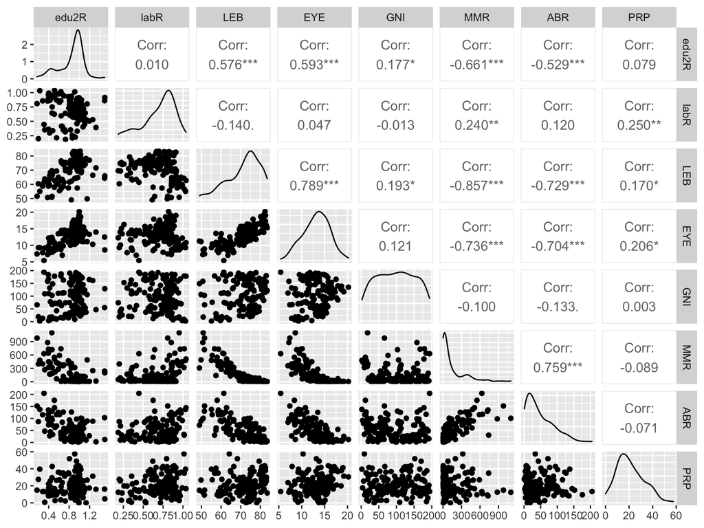

```r
# graphical overview with
p <- ggpairs(human, lower = list(combo = wrap("facethist", bins = 20)))
p
```

These same observations can be made also from the correlation matrix presented below.

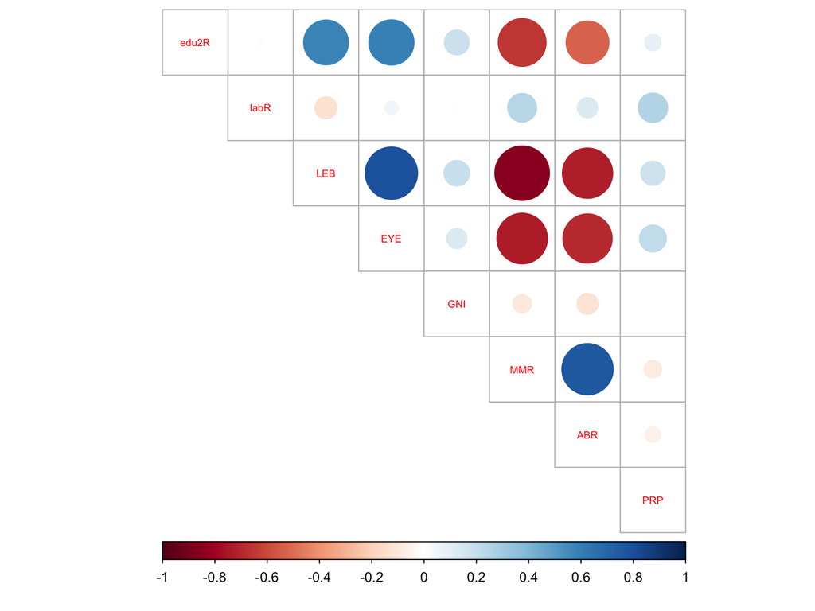

```r
#plotting the correlation matrix
cor_matrix <- cor(human) %>% round(digits = 2)

corrplot(cor_matrix, method="circle", type="upper", cl.pos="b", tl.pos="d", tl.cex = 0.6)
```

## 2 PCA analysis (2p)

Doing a PCA analysis on the data:

```r
pca_human <- prcomp(human)

# making a summary of the PCA
s <- summary(pca_human)

# printing rounded percentages of variance captured by each principal component
pca_pr <- round(100*s$importance[2, ], digits = 1)
pca_pr
```

```
##  PC1  PC2  PC3  PC4  PC5  PC6  PC7  PC8
## 92.3  6.0  1.4  0.3  0.0  0.0  0.0  0.0
```

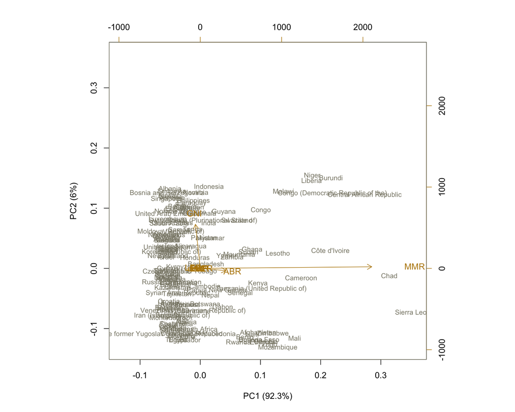

```r
# making the lables include the percentages
pc_lab <- paste0(names(pca_pr), " (", pca_pr, "%)")

# draw a biplot
biplot(pca_human, cex = c(0.8, 1),
       col = c("cornsilk4", "darkgoldenrod"),
       xlab = pc_lab[1],
       ylab = pc_lab[2])
```

PCA biplot of human development data shows the first two principal components, that together cover 98% of variation in the data. Gross National Income has mostly effect on the PC2 and maternal mortality rate is the strongest contributor to the PC1. The other variables have a very small eigenvalues (the vectors).

## 3 Standartizing the variables & PCA (4p)

Next the variables will be standardized and the same PCA analysis done again.

```r
human_std <- scale(human)
pca_human_std <- prcomp(human_std)

# making a summary of the PCA
s_ <- summary(pca_human_std)

# printing rounded percentages of variance captured by each principal component
pca_pr_ <- round(100*s_$importance[2, ], digits = 1)
pca_pr_
```

```
##  PC1  PC2  PC3  PC4  PC5  PC6  PC7  PC8
## 48.3 16.2 12.3  9.4  6.1  3.6  2.7  1.4
```

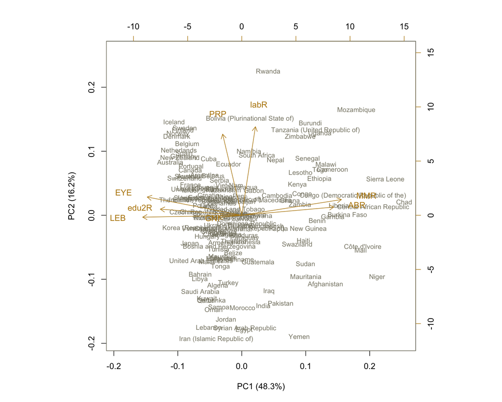

```r
# making the lables include the percentages
pc_lab_ <- paste0(names(pca_pr_), " (", pca_pr_, "%)")

# draw a biplot
biplot(pca_human_std,
       cex = c(0.8, 1),
       col = c("cornsilk4", "darkgoldenrod"),
       xlab = pc_lab_[1],
       ylab = pc_lab_[2])
```

The results are looking quite different. Standardizing brings all the observations to the same range, and therefore it is easier to see the differences and correlations between them, and their ifluence on the principal components. PCA biplot of scaled human development data shows the first two principal components that explain together approximately 64 % of the total variation in the data. After standardizing there are more principal components with some effects (shown in the percentages above the graph) than without standardizing. In general it doesn’t really make sense to analyse the results of non-standardised PCA.

## 4 Interpretation (2p)

The arrows pointing to the same direction as the principal component axis represent the features contributing to that PC. Then again the arrows having a small angle between their directions are strongly correlated with each other. The length of the arrow tells about the standard deviation of the variable — longer arrow, higher standard deviation.

The **second principal component** is mostly defined by proportion of females in parliament and ratio of female vs male in labour force, aka it tells something about equality in worklife.

Then we can look at the principal components together and in relation to the observations (Countries). The lower half of the graph shows countries with less women in power, and the upper half more. The left hand countries have a high life expectancy and good level on education, and the right hand side countries are not as developed education- or maternity-wise. Following from this, the countries with high education levels and high ratio of women in parliament are located in the upper left part of the graph and can be thought as the most developed, based on these indicators. At the opposite end of the graph, lower right, there are countries with high maternal mortality rates, higher adolescent birth rate and less women in power. These countries can be said to be the least developed.

This analysis complements the descriptive analysis done based on the correlation matrix, and offers more insight to the data — PCA analysis helps in seeing overarching themes rising from the data.

## 5 MCA on tea data (4p)

Checking on the tea data and Multiple Correspondence Analysis on the data:

```r
data(tea)

str(tea)
```

```
## 'data.frame':    300 obs. of  36 variables:
##  $ breakfast       : Factor w/ 2 levels "breakfast","Not.breakfast": 1 1 2 2 1 2 1 2 1 1 ...
##  $ tea.time        : Factor w/ 2 levels "Not.tea time",..: 1 1 2 1 1 1 2 2 2 1 ...
##  $ evening         : Factor w/ 2 levels "evening","Not.evening": 2 2 1 2 1 2 2 1 2 1 ...
##  $ lunch           : Factor w/ 2 levels "lunch","Not.lunch": 2 2 2 2 2 2 2 2 2 2 ...
##  $ dinner          : Factor w/ 2 levels "dinner","Not.dinner": 2 2 1 1 2 1 2 2 2 2 ...
##  $ always          : Factor w/ 2 levels "always","Not.always": 2 2 2 2 1 2 2 2 2 2 ...
##  $ home            : Factor w/ 2 levels "home","Not.home": 1 1 1 1 1 1 1 1 1 1 ...
##  $ work            : Factor w/ 2 levels "Not.work","work": 1 1 2 1 1 1 1 1 1 1 ...
##  $ tearoom         : Factor w/ 2 levels "Not.tearoom",..: 1 1 1 1 1 1 1 1 1 2 ...
##  $ friends         : Factor w/ 2 levels "friends","Not.friends": 2 2 1 2 2 2 1 2 2 2 ...
##  $ resto           : Factor w/ 2 levels "Not.resto","resto": 1 1 2 1 1 1 1 1 1 1 ...
##  $ pub             : Factor w/ 2 levels "Not.pub","pub": 1 1 1 1 1 1 1 1 1 1 ...
##  $ Tea             : Factor w/ 3 levels "black","Earl Grey",..: 1 1 2 2 2 2 2 1 2 1 ...
##  $ How             : Factor w/ 4 levels "alone","lemon",..: 1 3 1 1 1 1 1 3 3 1 ...
```

[output cut: 22 more lines]

```r
dim(tea) # observations 300, variables 36
```

```
## [1] 300  36
```

```r
# selecting the following columns to keep for the analysis
keep_columns <- c("Tea", "How", "how", "sophisticated", "where", "spirituality")

# creating the new dataset based on the wanted variables
#FOR SOME REASON THIS PART IS CRASHING WHEN I KNIT THE index FILE, BUT WORKS IF I ONLY KNIT chapter5 FILE...

#tea_time <- select(tea, one_of(keep_columns))

#MCA on the data
#mca <- MCA(tea_time, graph = FALSE)

#making a plot about the results
#plot(mca, invisible=c("ind"), habillage = "quali", graph.type = "classic")
```

Since I had problems with running the index file even though the scripts works well when kinning only chapter5 file, I will attach a picture of the results instead:

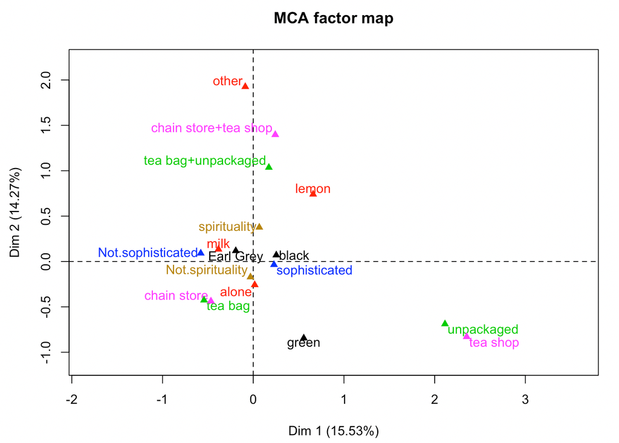

**MCA plot of the selected variables of the tea data.**

From the visualization we can see that using tea bags for making the tea goes hand in hand with buying the tea from a chain store, and similarly using unpacked tea and shopping in specific tea shops are very close. These make a lot of sense since most loose-leaf teas are sold in tea shops.

Black tea is close to sophisticated and milk usage rather close to not-sophisticated. Green tea and using lemon both stand out from the other variables.

These are maybe not the most interesting variables for the Multiple Correspondence analysis, and some others could have been chosen instead.

**END OF WEEK 5!**